# R Mini Project - Covid World Vaccination Progress

##### **114 - Oveshahmed Patel**

##### **115 - Shloka Singh**

##### **116 - Janhavi Zarapkar**

**Importing Libraries and The data set**

We are using realtime Kaggle / Github which gets updated daily

Github: https://github.com/owid/covid-19-data/tree/master/public/data/vaccinations

Kaggle: https://www.kaggle.com/gpreda/covid-world-vaccination-progress?select=country_vaccinations.csv

```r
packages <- c('dplyr','ggplot2','tidyverse','countrycode','IRdisplay','htmlwidgets','plotly','tidyr','choroplethr','choroplethrMaps','lubridate','choroplethr','readr','skimr','naniar','ggmap','RColorBrewer','rworldmap','reshape2')

install_package <- packages %in% row.names(installed.packages())
if (any (install_package ==  FALSE))
  install.packages(packages[!install_package])
library("corrplot")
library("caret")
library("caTools")
sapply(packages, require, character.only = TRUE)
```

```
          dplyr         ggplot2       tidyverse     countrycode       IRdisplay     htmlwidgets          plotly           tidyr     choroplethr
           TRUE            TRUE            TRUE            TRUE            TRUE            TRUE            TRUE            TRUE            TRUE
choroplethrMaps       lubridate     choroplethr           readr           skimr          naniar           ggmap    RColorBrewer       rworldmap
           TRUE            TRUE            TRUE            TRUE            TRUE            TRUE            TRUE            TRUE            TRUE
       reshape2
           TRUE
```

**DATA GATHERING**

```r
data <- read_csv("./input/vaccinations.csv")
head(data)
```

| location | iso_code | date | total_vaccinations | people_vaccinated | people_fully_vaccinated | daily_vaccinations_raw | daily_vaccinations | total_vaccinations_per_hundred | people_vaccinated_per_hundred | people_fully_vaccinated_per_hundred | daily_vaccinations_per_million | vaccines |
| --- | --- | --- | --- | --- | --- | --- | --- | --- | --- | --- | --- | --- |
| Afghanistan | AFG | 2021-02-22 | 0 | 0 | NA | NA | NA | 0 | 0 | NA | NA | Oxford/AstraZeneca |
| Afghanistan | AFG | 2021-02-23 | NA | NA | NA | NA | 1367 | NA | NA | NA | 35 | Oxford/AstraZeneca |
| Afghanistan | AFG | 2021-02-24 | NA | NA | NA | NA | 1367 | NA | NA | NA | 35 | Oxford/AstraZeneca |
| Afghanistan | AFG | 2021-02-25 | NA | NA | NA | NA | 1367 | NA | NA | NA | 35 | Oxford/AstraZeneca |
| Afghanistan | AFG | 2021-02-26 | NA | NA | NA | NA | 1367 | NA | NA | NA | 35 | Oxford/AstraZeneca |
| Afghanistan | AFG | 2021-02-27 | NA | NA | NA | NA | 1367 | NA | NA | NA | 35 | Oxford/AstraZeneca |

**Inspect the structure of data**

```r
#Inspect the structure of data
str(data)
```

```
spec_tbl_df[,13] [16,060 x 13] (S3: spec_tbl_df/tbl_df/tbl/data.frame)
 $ location                           : chr [1:16060] "Afghanistan" "Afghanistan" "Afghanistan" "Afghanistan" ...
 $ iso_code                           : chr [1:16060] "AFG" "AFG" "AFG" "AFG" ...
 $ date                               : Date[1:16060], format: "2021-02-22" "2021-02-23" "2021-02-24" "2021-02-25" ...
 $ total_vaccinations                 : num [1:16060] 0 NA NA NA NA NA 8200 NA NA NA ...
 $ people_vaccinated                  : num [1:16060] 0 NA NA NA NA NA 8200 NA NA NA ...
 $ people_fully_vaccinated            : num [1:16060] NA NA NA NA NA NA NA NA NA NA ...
 $ daily_vaccinations_raw             : num [1:16060] NA NA NA NA NA NA NA NA NA NA ...
 $ daily_vaccinations                 : num [1:16060] NA 1367 1367 1367 1367 ...
 $ total_vaccinations_per_hundred     : num [1:16060] 0 NA NA NA NA NA 0.02 NA NA NA ...
 $ people_vaccinated_per_hundred      : num [1:16060] 0 NA NA NA NA NA 0.02 NA NA NA ...
 $ people_fully_vaccinated_per_hundred: num [1:16060] NA NA NA NA NA NA NA NA NA NA ...
 $ daily_vaccinations_per_million     : num [1:16060] NA 35 35 35 35 35 35 41 46 52 ...
 $ vaccines                           : chr [1:16060] "Oxford/AstraZeneca" "Oxford/AstraZeneca" "Oxford/AstraZeneca" "Oxford/AstraZeneca" ...
 - attr(*, "spec")=
  .. cols(
  ..   location = col_character(),
  ..   iso_code = col_character(),
  ..   date = col_date(format = ""),
  ..   total_vaccinations = col_double(),
  ..   people_vaccinated = col_double(),
  ..   people_fully_vaccinated = col_double(),
  ..   daily_vaccinations_raw = col_double(),
  ..   daily_vaccinations = col_double(),
  ..   total_vaccinations_per_hundred = col_double(),
  ..   people_vaccinated_per_hundred = col_double(),
  ..   people_fully_vaccinated_per_hundred = col_double(),
  ..   daily_vaccinations_per_million = col_double(),
  ..   vaccines = col_character()
  .. )
```

**Inspect the dimensions of the data**

```r
#Inspect the dimensions of the data
dim (data)
```

```
[1] 16060    13
```

```r
colnames(data)
```

```
 [1] "location"                            "iso_code"                            "date"                                "total_vaccinations"
 [5] "people_vaccinated"                   "people_fully_vaccinated"             "daily_vaccinations_raw"              "daily_vaccinations"
 [9] "total_vaccinations_per_hundred"      "people_vaccinated_per_hundred"       "people_fully_vaccinated_per_hundred" "daily_vaccinations_per_million"
[13] "vaccines"
```

**Counting Total NA in the entire data set**

```r
# Total NA in the entire data set
data1 <- data
data_vaccine <- data
paste("Total NA count:: ",sum(is.na(data_vaccine)))
```

```
[1] "Total NA count::  53368"
```

**% of NA’s in entire dataset**

```r
# % of NA's in entire dataset
((sum(is.na(data_vaccine)) / prod(dim(data_vaccine))) * 100) %>%
round (2)
```

```
[1] 25.56
```

**NA’s per feature can also be visualised as below**

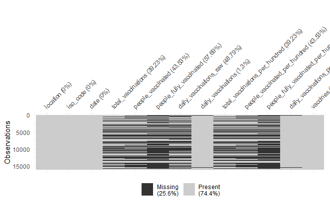

```r
vis_miss(data_vaccine)
```

**Total Number of NAs per Feature**

```r
  data.frame("Total_NA" = colSums(is.na(data_vaccine))) %>%
    mutate ("Percentage_of_NA" = (colSums(is.na(data_vaccine))/dim(data_vaccine)[1]) %>%
            round (3) * 100)
```

|  | Total_NA | Percentage_of_NA |
| --- | --- | --- |
| location | 0 | 0.0 |
| iso_code | 0 | 0.0 |
| date | 0 | 0.0 |
| total_vaccinations | 6301 | 39.2 |
| people_vaccinated | 6991 | 43.5 |
| people_fully_vaccinated | 9265 | 57.7 |
| daily_vaccinations_raw | 7836 | 48.8 |
| daily_vaccinations | 209 | 1.3 |
| total_vaccinations_per_hundred | 6301 | 39.2 |
| people_vaccinated_per_hundred | 6991 | 43.5 |

[output cut: 3 more lines]

**Countries for which the data is collected**

```r
# Countries for which the data is collected

location <- unique(data_vaccine$location)
location
```

```
  [1] "Afghanistan"                      "Albania"                          "Algeria"                          "Andorra"
  [5] "Angola"                           "Anguilla"                         "Antigua and Barbuda"              "Argentina"
  [9] "Armenia"                          "Aruba"                            "Australia"                        "Austria"
 [13] "Azerbaijan"                       "Bahamas"                          "Bahrain"                          "Bangladesh"
 [17] "Barbados"                         "Belarus"                          "Belgium"                          "Belize"
 [21] "Bermuda"                          "Bhutan"                           "Bolivia"                          "Bosnia and Herzegovina"
 [25] "Botswana"                         "Brazil"                           "Brunei"                           "Bulgaria"
 [29] "Cambodia"                         "Cameroon"                         "Canada"                           "Cape Verde"
 [33] "Cayman Islands"                   "Chile"                            "China"                            "Colombia"
 [37] "Comoros"                          "Congo"                            "Costa Rica"                       "Cote d'Ivoire"
 [41] "Croatia"                          "Curacao"                          "Cyprus"                           "Czechia"
 [45] "Democratic Republic of Congo"     "Denmark"                          "Djibouti"                         "Dominica"
 [49] "Dominican Republic"               "Ecuador"                          "Egypt"                            "El Salvador"
 [53] "England"                          "Equatorial Guinea"                "Estonia"                          "Eswatini"
 [57] "Ethiopia"                         "Faeroe Islands"                   "Falkland Islands"                 "Fiji"
```

[output cut: 35 more lines]

**Analysing UK and its Sovient Countries**

As we analysed our dataset we got to know that there is UK and their sovient countries

```r
# There is United kingdom and also its sovient countries included in the data,
# let us verify if they have same number of records included

 # There is United kingdom and also its sovient countries included in the data,
# let us verify if they have same number of records included
data_vaccine %>%
filter (location %in% c('United Kingdom','Northern Ireland','Wales','Scotland'))%>%
group_by(location)%>%
count()
```

| location | n |
| --- | --- |
| Northern Ireland | 125 |
| Scotland | 125 |
| United Kingdom | 125 |
| Wales | 124 |

```r
NA
NA
```

**Data Cleaning**

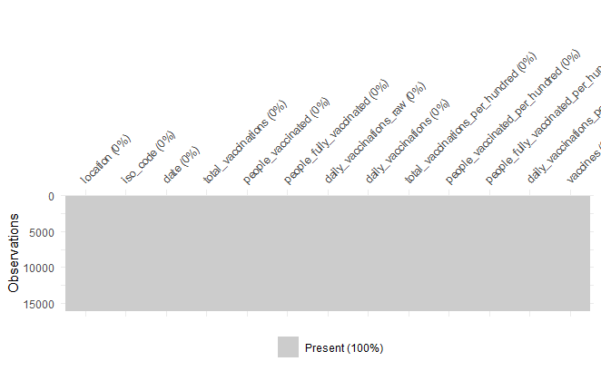

```r
#Data Cleaning
#There are few steps in this section:

#As shown by .head() method, our data obviously contains missing values, so we'll need to deal with it somehow
#Some of the country names appeared in the dataset, does not represent a single country (constituent countries) and also the union territories
#Multiple vaccines are updated in a single row and needs to be separated

# Handling the missing values

data_vaccine[is.na(data_vaccine)] = 0

vis_miss(data_vaccine)
```

```r
# there are no more NA in the data set
```

```r
# Removing the UK soviet countries
# I also consider to eliminate Gibraltar, Isle of Man, Cayman Islands, Falkland Islands, Guernsey,
# Saint Helena, Turks and Caicos Islands (UK pertinence), Faeroe Islands (Denmark pertinence).
remove_countries = c('England','Northern Ireland','Scotland','Wales','Falkland Islands','Faeroe Islands','Isle of Man','Cayman Islands','Saint Helena','Saint Lucia','Saint Vincent and the Grenadines','Saint Kitts and Nevis')

data_vaccine <-data_vaccine %>%
  filter (!location %in% remove_countries)

unique(data_vaccine$location)
```

```
  [1] "Afghanistan"                  "Albania"                      "Algeria"                      "Andorra"
  [5] "Angola"                       "Anguilla"                     "Antigua and Barbuda"          "Argentina"
  [9] "Armenia"                      "Aruba"                        "Australia"                    "Austria"
 [13] "Azerbaijan"                   "Bahamas"                      "Bahrain"                      "Bangladesh"
 [17] "Barbados"                     "Belarus"                      "Belgium"                      "Belize"
 [21] "Bermuda"                      "Bhutan"                       "Bolivia"                      "Bosnia and Herzegovina"
 [25] "Botswana"                     "Brazil"                       "Brunei"                       "Bulgaria"
 [29] "Cambodia"                     "Cameroon"                     "Canada"                       "Cape Verde"
 [33] "Chile"                        "China"                        "Colombia"                     "Comoros"
 [37] "Congo"                        "Costa Rica"                   "Cote d'Ivoire"                "Croatia"
 [41] "Curacao"                      "Cyprus"                       "Czechia"                      "Democratic Republic of Congo"
 [45] "Denmark"                      "Djibouti"                     "Dominica"                     "Dominican Republic"
 [49] "Ecuador"                      "Egypt"                        "El Salvador"                  "Equatorial Guinea"
 [53] "Estonia"                      "Eswatini"                     "Ethiopia"                     "Fiji"
 [57] "Finland"                      "France"                       "Gabon"                        "Gambia"
```

[output cut: 32 more lines]

**Vaccines Used Worldwide**

```r
# Below the Vaccines use world wide
    data_vaccine$vaccines <- str_replace_all(data_vaccine$vaccines, " ","")
    # remove all spaces in between
    vaccine_val<- unique(data_vaccine$vaccines)
    vaccine<- vector()

    for (i in vaccine_val){
        for (j in strsplit(i, ",")){
            vaccine<- c(vaccine, j)
        }
    }
    vaccine_used<- unique(vaccine)
    vaccine_used
```

```
 [1] "Oxford/AstraZeneca" "SputnikV"           "Pfizer/BioNTech"    "Sinopharm/Beijing"  "Johnson&Johnson"    "Moderna"            "Sinovac"
 [8] "Sinopharm/Wuhan"    "Covaxin"            "CanSino"            "EpiVacCorona"
```

```r
# Inspect the usage of vaccine used wordwide

vaccine_data_val <- data.frame(matrix(ncol = length(vaccine_used), nrow = 0))
for (i in data_vaccine$vaccines){
  vaccine_data_val<- rbind(vaccine_data_val, Vectorize(grepl, USE.NAMES = TRUE)(vaccine_used, str_replace_all(i," ","")))
}
vaccine_data_val[vaccine_data_val == TRUE] = 1
vaccine_data_val[vaccine_data_val == FALSE] =0
colnames(vaccine_data_val) <- paste0(unique(vaccine))
```

**Percentage of Vaccines used Worldwide**

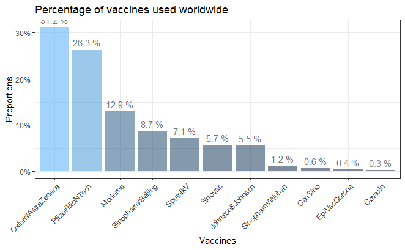

```r
vaccine_data_val %>%
summarise_all(sum)%>%
gather(key="Vaccine_name", value = "Vaccine_count")%>%
mutate (Vaccine_count1 = round(Vaccine_count/sum(Vaccine_count),3))%>%
ggplot(mapping=aes(x=reorder(Vaccine_name,-Vaccine_count1), y=Vaccine_count1, fill =Vaccine_count1, alpha=0.7))+
geom_col()+
labs(x = "Vaccines", y = "Proportions", title  = "Percentage of vaccines used worldwide")+
geom_text(aes(label = paste(Vaccine_count1*100,"%")), vjust=-0.5)+
scale_y_continuous(labels = scales::percent) +
theme_bw()+
theme(axis.text.x = element_text(angle = 45, hjust = 1), legend.position = "None")
```

**Number of Countries Using these Vaccines**

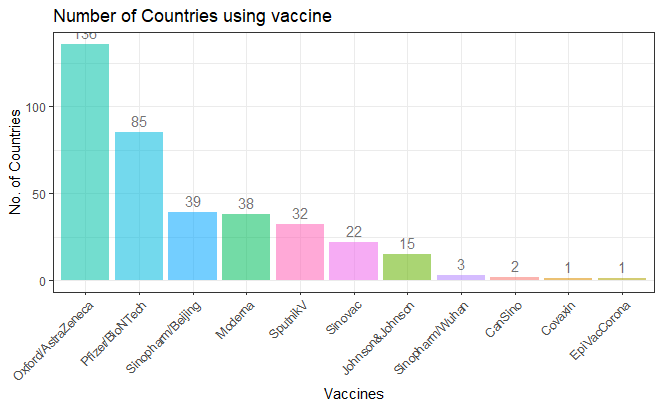

```r
# No of countries using these vaccines



vaccine_in_countries<- vaccine_data_val %>%
mutate(country = data_vaccine$location)%>%
group_by(country)%>%
summarise_all(sum)

data <- data.frame("No_of_countries"= apply(vaccine_in_countries[-1],2, function(c)sum(c!=0)))
cbind("Vaccine"=row.names(data),data) %>%
ggplot(mapping=aes(x=reorder(Vaccine, -No_of_countries), y=No_of_countries, fill = Vaccine, alpha=0.5))+
geom_col() +
labs(x = "Vaccines", y = "No. of Countries", title  = "Number of Countries using vaccine")+
geom_text(aes(label = No_of_countries), vjust=-0.5)+
theme_bw()+
theme(axis.text.x = element_text(angle = 45, hjust = 1), legend.position = "None")
```

**Spread of Vaccine across the world**

```r
#Spread of Vaccine accrosss the world


#Spread of Vaccine accrosss the world

head(data_vaccine)
```

| location | iso_code | date | total_vaccinations | people_vaccinated | people_fully_vaccinated | daily_vaccinations_raw | daily_vaccinations | total_vaccinations_per_hundred | people_vaccinated_per_hundred | people_fully_vaccinated_per_hundred | daily_vaccinations_per_million | vaccines |
| --- | --- | --- | --- | --- | --- | --- | --- | --- | --- | --- | --- | --- |
| Afghanistan | AFG | 2021-02-22 | 0 | 0 | 0 | 0 | 0 | 0 | 0 | 0 | 0 | Oxford/AstraZeneca |
| Afghanistan | AFG | 2021-02-23 | 0 | 0 | 0 | 0 | 1367 | 0 | 0 | 0 | 35 | Oxford/AstraZeneca |
| Afghanistan | AFG | 2021-02-24 | 0 | 0 | 0 | 0 | 1367 | 0 | 0 | 0 | 35 | Oxford/AstraZeneca |
| Afghanistan | AFG | 2021-02-25 | 0 | 0 | 0 | 0 | 1367 | 0 | 0 | 0 | 35 | Oxford/AstraZeneca |
| Afghanistan | AFG | 2021-02-26 | 0 | 0 | 0 | 0 | 1367 | 0 | 0 | 0 | 35 | Oxford/AstraZeneca |
| Afghanistan | AFG | 2021-02-27 | 0 | 0 | 0 | 0 | 1367 | 0 | 0 | 0 | 35 | Oxford/AstraZeneca |

```r
NA
NA
```

```r
world_data<- data_vaccine[,c(1,2,length(data_vaccine))] %>%
distinct()%>%
separate_rows(vaccines, sep=",")
world_data
```

| location | iso_code | vaccines |
| --- | --- | --- |
| Afghanistan | AFG | Oxford/AstraZeneca |
| Albania | ALB | Oxford/AstraZeneca |
| Algeria | DZA | SputnikV |
| Andorra | AND | Oxford/AstraZeneca |
| Andorra | AND | Pfizer/BioNTech |
| Angola | AGO | Oxford/AstraZeneca |
| Anguilla | AIA | Oxford/AstraZeneca |
| Antigua and Barbuda | ATG | Oxford/AstraZeneca |
| Argentina | ARG | Oxford/AstraZeneca |
| Argentina | ARG | Sinopharm/Beijing |

[output cut: 364 more lines]

**Plotting Countries using a particular vaccine**

```
133 codes from your data successfully matched countries in the map
3 codes from your data failed to match with a country code in the map
110 codes from the map weren't represented in your data
31 codes from your data successfully matched countries in the map
1 codes from your data failed to match with a country code in the map
212 codes from the map weren't represented in your data
```

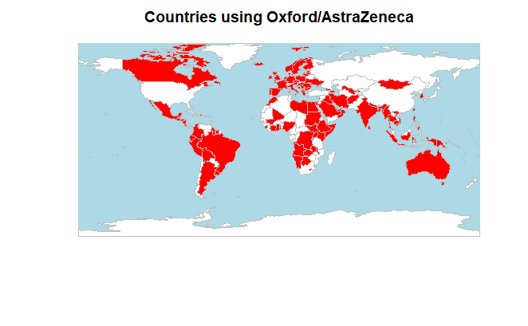

```
82 codes from your data successfully matched countries in the map
3 codes from your data failed to match with a country code in the map
161 codes from the map weren't represented in your data
```

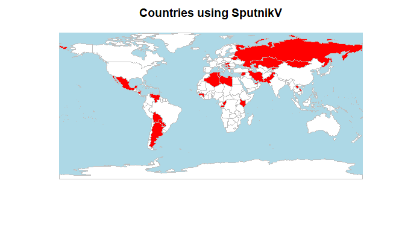

```
38 codes from your data successfully matched countries in the map
1 codes from your data failed to match with a country code in the map
205 codes from the map weren't represented in your data
```

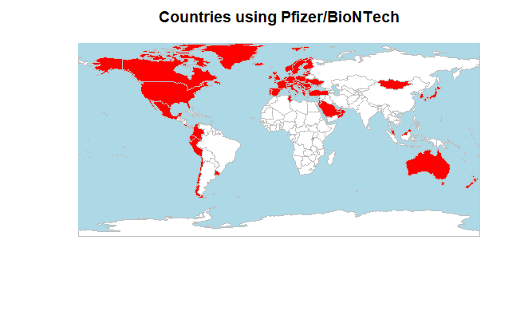

```
14 codes from your data successfully matched countries in the map
1 codes from your data failed to match with a country code in the map
229 codes from the map weren't represented in your data
```

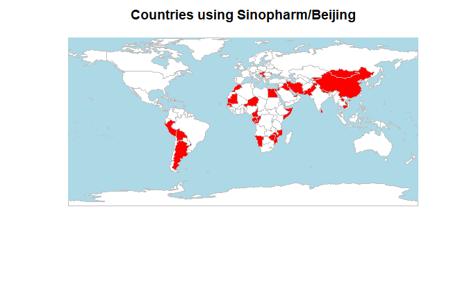

```
37 codes from your data successfully matched countries in the map
1 codes from your data failed to match with a country code in the map
206 codes from the map weren't represented in your data
```

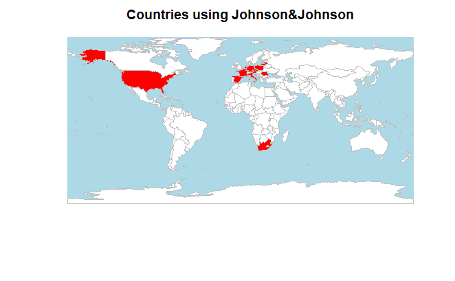

```
21 codes from your data successfully matched countries in the map
1 codes from your data failed to match with a country code in the map
222 codes from the map weren't represented in your data
```

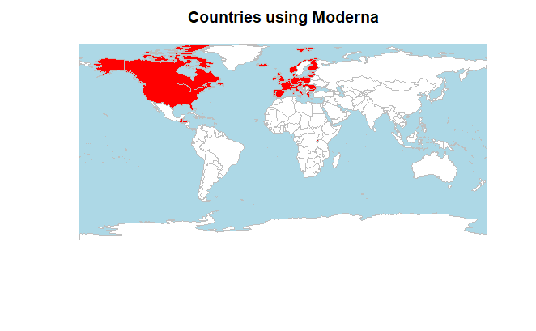

```
2 codes from your data successfully matched countries in the map
1 codes from your data failed to match with a country code in the map
241 codes from the map weren't represented in your data
```

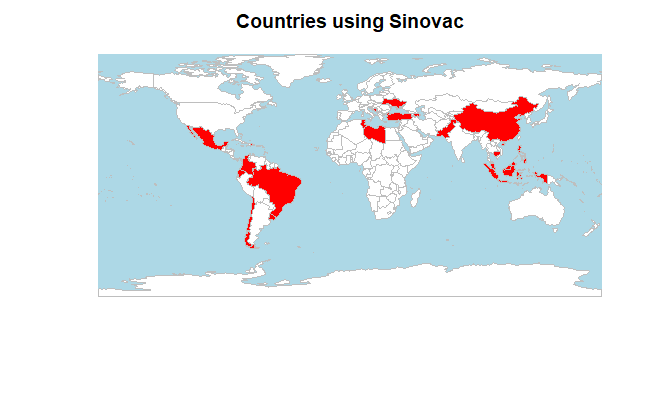

```
1 codes from your data successfully matched countries in the map
0 codes from your data failed to match with a country code in the map
242 codes from the map weren't represented in your data
```

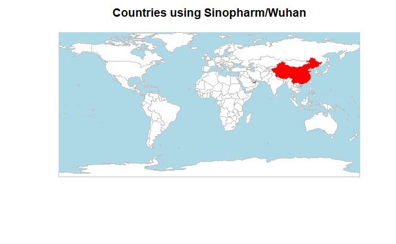

```
2 codes from your data successfully matched countries in the map
0 codes from your data failed to match with a country code in the map
241 codes from the map weren't represented in your data
```

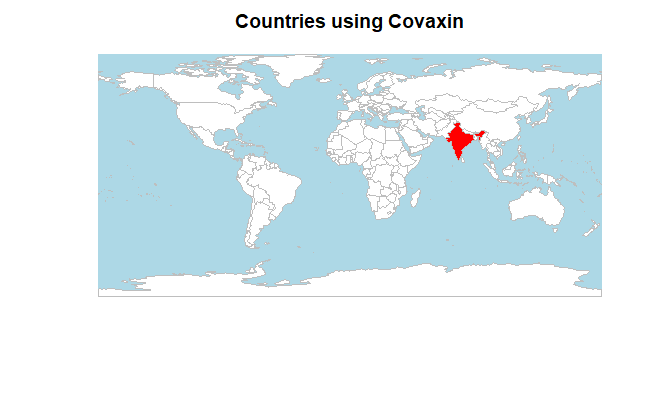

```
1 codes from your data successfully matched countries in the map
0 codes from your data failed to match with a country code in the map
242 codes from the map weren't represented in your data
```

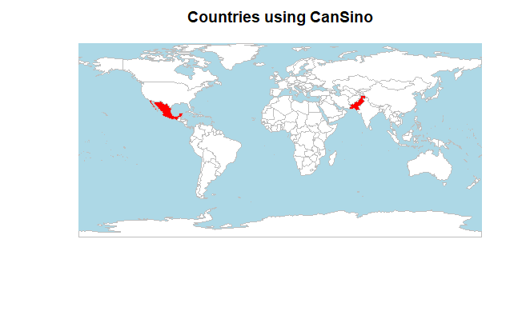

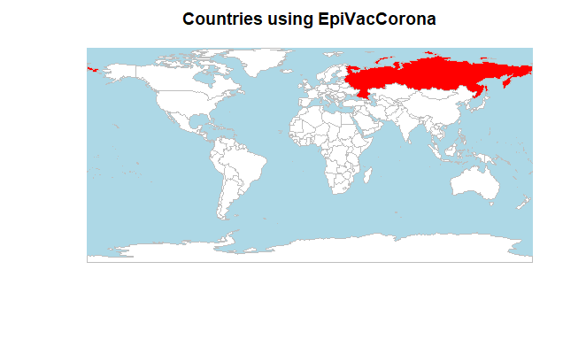

```r
options(repr.plot.width=20, repr.plot.height=8)

plot_world_map <- function(iso,vacc) {
  d <- joinCountryData2Map(iso, joinCode = "ISO3",
      nameJoinColumn = "iso_code", verbose= FALSE)
  mapCountryData(d, nameColumnToPlot="vaccines", catMethod = "categorical",
    missingCountryCol = "white", addLegend = FALSE, mapTitle = paste("Countries using", vacc), oceanCol="lightblue")
    identifyCountries(d, nameCountryColumn = "iso_code",plotSelected = TRUE)
}

for (vac in vaccine_used){
    plot_world_map(world_data[world_data$vaccines == vac,],vac)
}
```

**Total vaccination in the countries**

```r
data_vaccine <- data_vaccine %>%
  select(location, iso_code, date, total_vaccinations,people_vaccinated_per_hundred, daily_vaccinations) %>%
  group_by(location) %>%
  filter(!is.na(total_vaccinations)) %>%
  filter(total_vaccinations == max(total_vaccinations))
```

**Recent Update made in the Dataset**

```r
d <-as.Date(data_vaccine$date)
recent.date <- max(d)
recent.date
```

```
[1] "2021-05-08"
```

# **Top 20 Most Vaccinated Countries**

Plot of total vaccinations for the top 20 most vaccinated countries as of the most recent update.

```r
df_total_vaccinations <-data_vaccine[!(data_vaccine$location=="World"),]
df_total_vaccinations
```

| location | iso_code | date | total_vaccinations | people_vaccinated_per_hundred | daily_vaccinations |
| --- | --- | --- | --- | --- | --- |
| Afghanistan | AFG | 2021-04-22 | 240000 | 0.62 | 8000 |
| Albania | ALB | 2021-05-08 | 596766 | 0.00 | 14677 |
| Algeria | DZA | 2021-02-19 | 75000 | 0.00 | 3748 |
| Andorra | AND | 2021-05-03 | 28881 | 31.30 | 54 |
| Angola | AGO | 2021-04-23 | 456349 | 1.39 | 16736 |
| Anguilla | AIA | 2021-04-22 | 6898 | 40.76 | 106 |
| Antigua and Barbuda | ATG | 2021-04-22 | 29754 | 30.38 | 250 |
| Argentina | ARG | 2021-05-08 | 9001747 | 16.95 | 147182 |
| Armenia | ARM | 2021-03-31 | 565 | 0.02 | 0 |
| Aruba | ABW | 2021-05-08 | 80699 | 52.21 | 507 |

[output cut: 174 more lines]

**Total Vaccinations per Country**

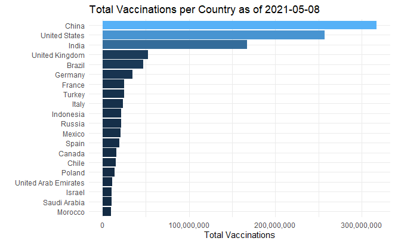

```r
df_total_vaccinations %>%
  arrange(desc(total_vaccinations)) %>%
head(20)%>%
  ggplot(aes(total_vaccinations, reorder(location, total_vaccinations))) + theme_minimal() +
  geom_bar(stat = 'identity', aes(fill=total_vaccinations)) + scale_x_continuous(labels = scales::comma) +
  labs(title = paste('Total Vaccinations per Country as of', recent.date, sep = " "), y = '', x = 'Total Vaccinations') +
  theme(legend.position = 'none')
```

**Let’s take a look at vaccinations per hundred people to see how the percentages look.**

```r
data_vaccine$people_vaccinated_per_hundred
```

```
  [1]   0.62   0.00   0.00  31.30   1.39  40.76  30.38  16.95   0.02  52.21   0.00  29.44   9.88   6.53  46.28   3.53  26.20   2.58  30.44  11.73  52.79  62.39
 [23]   5.46   2.54   2.12  14.92   2.45   9.25  10.28   0.04  38.18   0.39  44.24   0.00   7.59   1.55   0.26  11.88   0.82  21.13  46.61  24.93  24.15   0.00
 [45]  25.55   1.04  25.69  13.97   5.40   0.64  14.78   4.61  28.06   3.01   0.00   6.25  35.08  25.72   0.31   0.87   1.37  32.07   2.73 114.14  23.51  15.84
 [67]  11.55   1.13  49.17   0.87  15.76   0.56  14.08  44.12  40.61   9.66   4.82   1.47   0.74  26.43  62.61  27.40   4.57   2.44  52.33   7.89   8.71   1.59
 [89]   1.14   0.00   0.41   1.73  16.54   4.77   0.75   0.01  25.29  28.32  26.42  11.79   1.63   3.29  55.58   0.25  26.77   0.15   9.23  10.64   4.00  32.51
[111]  46.88  11.60  25.87  14.83   0.18   1.84   1.35   6.46   7.18  25.96   4.51   2.04   0.01   0.63   4.66  18.60  27.04   4.95   0.00   3.33  11.92   0.03
[133]   1.84   3.90   1.78  26.91  27.36  38.31  18.35   8.95   2.71   0.00  63.02   4.44   0.00   2.53  31.45  69.19   0.69  23.32  22.15  23.19   0.71   0.74
[155]   0.64   7.17   0.01  28.39   4.33   0.32   7.74  28.25  23.08   0.01   0.00   1.82   0.20   1.93   5.08   4.27   2.82  17.25  38.84   0.85   1.97   0.00
[177]  51.84  45.24  35.31   1.79   0.88   0.52   8.28   0.42   3.37
```

**Total Vaccination Percentage Per Country**

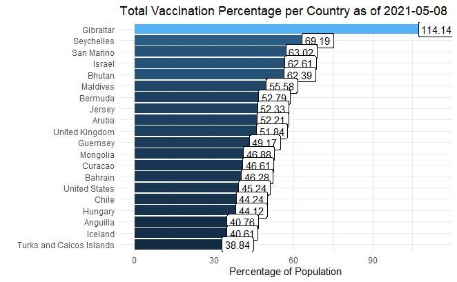

```r
df_vacc_perc <- data_vaccine %>%
  select(location, iso_code, date, people_vaccinated_per_hundred) %>%
  group_by(location) %>%
  filter(!is.na(people_vaccinated_per_hundred)) %>%
  filter(people_vaccinated_per_hundred == max(people_vaccinated_per_hundred)) %>%
  distinct(location, .keep_all = TRUE)

#Plot of total vaccinations per hundred people for top 20 most vaccinated countries as of most recent update.
df_vacc_perc %>%
  arrange(desc(people_vaccinated_per_hundred)) %>%
  head(20) %>%
  ggplot(aes(people_vaccinated_per_hundred, reorder(location, people_vaccinated_per_hundred))) + theme_minimal() +
  geom_col(aes(fill=people_vaccinated_per_hundred)) + geom_label(aes(label = people_vaccinated_per_hundred)) +
  labs(title = paste('Total Vaccination Percentage per Country as of', recent.date, sep = " "), y = '', x = 'Percentage of Population') +
  theme(legend.position = 'none')
```

# **Average Daily Vaccinations**

Let’s see how the top countries are doing as far as daily vaccinations.

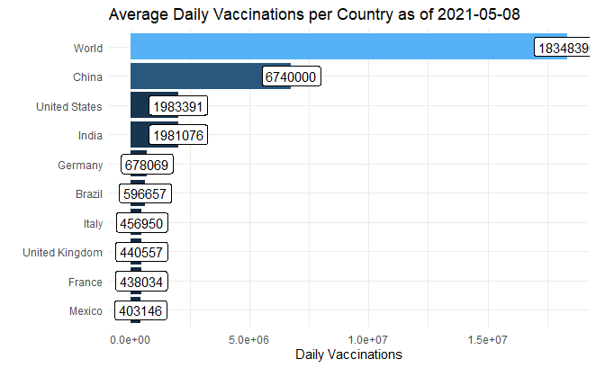

```r
#Daily Vaccinations
df_vacc_daily <- data_vaccine %>%
  select(location, daily_vaccinations) %>%
  group_by(location) %>%
  filter(!is.na(daily_vaccinations))

#Aggregate data by country name and average them.
df_vacc_daily <- aggregate(list(daily_vaccinations = df_vacc_daily$daily_vaccinations), list(location = df_vacc_daily$location), mean)

#Plot of average daily vaccinations for each country.
df_vacc_daily %>%
  arrange(desc(daily_vaccinations)) %>%
  head(10) %>%
  ggplot(aes(daily_vaccinations, reorder(location, daily_vaccinations))) + theme_minimal() +
  geom_col(aes(fill=daily_vaccinations)) + geom_label(aes(label = round(daily_vaccinations))) +
  labs(title = paste('Average Daily Vaccinations per Country as of', recent.date, sep = " "), y = '', x = 'Daily Vaccinations') +
  theme(legend.position = 'none')
```

**Feature Scaling for India**

```r
data_India <- data1%>% filter(data1$location  == "India")
data_India
```

| location | iso_code | date | total_vaccinations | people_vaccinated | people_fully_vaccinated | daily_vaccinations_raw | daily_vaccinations | total_vaccinations_per_hundred | people_vaccinated_per_hundred | people_fully_vaccinated_per_hundred | daily_vaccinations_per_million | vaccines |
| --- | --- | --- | --- | --- | --- | --- | --- | --- | --- | --- | --- | --- |
| India | IND | 2021-01-15 | 0 | 0 | NA | NA | NA | 0.00 | 0.00 | NA | NA | Covaxin, Oxford/AstraZeneca |
| India | IND | 2021-01-16 | 191181 | 191181 | NA | 191181 | 191181 | 0.01 | 0.01 | NA | 139 | Covaxin, Oxford/AstraZeneca |
| India | IND | 2021-01-17 | 224301 | 224301 | NA | 33120 | 112150 | 0.02 | 0.02 | NA | 81 | Covaxin, Oxford/AstraZeneca |
| India | IND | 2021-01-18 | 454049 | 454049 | NA | 229748 | 151350 | 0.03 | 0.03 | NA | 110 | Covaxin, Oxford/AstraZeneca |
| India | IND | 2021-01-19 | 674835 | 674835 | NA | 220786 | 168709 | 0.05 | 0.05 | NA | 122 | Covaxin, Oxford/AstraZeneca |
| India | IND | 2021-01-20 | 806484 | 806484 | NA | 131649 | 161297 | 0.06 | 0.06 | NA | 117 | Covaxin, Oxford/AstraZeneca |
| India | IND | 2021-01-21 | 1043534 | 1043534 | NA | 237050 | 173922 | 0.08 | 0.08 | NA | 126 | Covaxin, Oxford/AstraZeneca |
| India | IND | 2021-01-22 | 1390592 | 1390592 | NA | 347058 | 198656 | 0.10 | 0.10 | NA | 144 | Covaxin, Oxford/AstraZeneca |
| India | IND | 2021-01-23 | 1582201 | 1582201 | NA | 191609 | 198717 | 0.11 | 0.11 | NA | 144 | Covaxin, Oxford/AstraZeneca |
| India | IND | 2021-01-24 | 1615504 | 1615504 | NA | 33303 | 198743 | 0.12 | 0.12 | NA | 144 | Covaxin, Oxford/AstraZeneca |

[output cut: 104 more lines]

```r
NA
```

```r
data_India[is.na(data_India)] = 0
data_India
```

| location | iso_code | date | total_vaccinations | people_vaccinated | people_fully_vaccinated | daily_vaccinations_raw | daily_vaccinations | total_vaccinations_per_hundred | people_vaccinated_per_hundred | people_fully_vaccinated_per_hundred | daily_vaccinations_per_million | vaccines |
| --- | --- | --- | --- | --- | --- | --- | --- | --- | --- | --- | --- | --- |
| India | IND | 2021-01-15 | 0 | 0 | 0 | 0 | 0 | 0.00 | 0.00 | 0.00 | 0 | Covaxin, Oxford/AstraZeneca |
| India | IND | 2021-01-16 | 191181 | 191181 | 0 | 191181 | 191181 | 0.01 | 0.01 | 0.00 | 139 | Covaxin, Oxford/AstraZeneca |
| India | IND | 2021-01-17 | 224301 | 224301 | 0 | 33120 | 112150 | 0.02 | 0.02 | 0.00 | 81 | Covaxin, Oxford/AstraZeneca |
| India | IND | 2021-01-18 | 454049 | 454049 | 0 | 229748 | 151350 | 0.03 | 0.03 | 0.00 | 110 | Covaxin, Oxford/AstraZeneca |
| India | IND | 2021-01-19 | 674835 | 674835 | 0 | 220786 | 168709 | 0.05 | 0.05 | 0.00 | 122 | Covaxin, Oxford/AstraZeneca |
| India | IND | 2021-01-20 | 806484 | 806484 | 0 | 131649 | 161297 | 0.06 | 0.06 | 0.00 | 117 | Covaxin, Oxford/AstraZeneca |
| India | IND | 2021-01-21 | 1043534 | 1043534 | 0 | 237050 | 173922 | 0.08 | 0.08 | 0.00 | 126 | Covaxin, Oxford/AstraZeneca |
| India | IND | 2021-01-22 | 1390592 | 1390592 | 0 | 347058 | 198656 | 0.10 | 0.10 | 0.00 | 144 | Covaxin, Oxford/AstraZeneca |
| India | IND | 2021-01-23 | 1582201 | 1582201 | 0 | 191609 | 198717 | 0.11 | 0.11 | 0.00 | 144 | Covaxin, Oxford/AstraZeneca |
| India | IND | 2021-01-24 | 1615504 | 1615504 | 0 | 33303 | 198743 | 0.12 | 0.12 | 0.00 | 144 | Covaxin, Oxford/AstraZeneca |

[output cut: 104 more lines]

**Summary**

```r
summary(data_India)
```

```
   location           iso_code              date            total_vaccinations  people_vaccinated   people_fully_vaccinated daily_vaccinations_raw
 Length:114         Length:114         Min.   :2021-01-15   Min.   :        0   Min.   :        0   Min.   :       0        Min.   :      0
 Class :character   Class :character   1st Qu.:2021-02-12   1st Qu.:  6347146   1st Qu.:  6347146   1st Qu.:       0        1st Qu.: 314600
 Mode  :character   Mode  :character   Median :2021-03-12   Median : 25026458   Median : 20519354   Median : 4507104        Median : 695154
                                       Mean   :2021-03-12   Mean   : 50413261   Mean   : 42735531   Mean   : 7677729        Mean   :1386684
                                       3rd Qu.:2021-04-09   3rd Qu.: 89418373   3rd Qu.: 78056524   3rd Qu.:11361849        3rd Qu.:2357620
                                       Max.   :2021-05-08   Max.   :167493857   Max.   :133366482   Max.   :34127375        Max.   :4265157
 daily_vaccinations total_vaccinations_per_hundred people_vaccinated_per_hundred people_fully_vaccinated_per_hundred daily_vaccinations_per_million
 Min.   :      0    Min.   : 0.0000                Min.   :0.0000                Min.   :0.0000                      Min.   :   0.0
 1st Qu.: 331002    1st Qu.: 0.4575                1st Qu.:0.4575                1st Qu.:0.0000                      1st Qu.: 239.8
 Median :1266792    Median : 1.8150                Median :1.4850                Median :0.3300                      Median : 918.0
 Mean   :1411753    Mean   : 3.6531                Mean   :3.0967                Mean   :0.5565                      Mean   :1023.0
 3rd Qu.:2220449    3rd Qu.: 6.4825                3rd Qu.:5.6575                3rd Qu.:0.8250                      3rd Qu.:1608.8
 Max.   :3659357    Max.   :12.1400                Max.   :9.6600                Max.   :2.4700                      Max.   :2652.0
   vaccines
 Length:114
 Class :character
 Mode  :character
```

```r
normalize <- function(x) {
  return((x-min(x))/ (max(x)-min(x)))
}
```

```r
normalize(data_India$people_vaccinated  )
```

```
  [1] 0.000000000 0.001433501 0.001681839 0.003404521 0.005060005 0.006047127 0.007824560 0.010426848 0.011863558 0.012113268 0.015174795 0.015217317
 [13] 0.017665451 0.021954939 0.026243678 0.028075525 0.028184315 0.029618806 0.031034169 0.033363345 0.037186592 0.040616270 0.043304149 0.043581880
 [25] 0.046930892 0.049574383 0.052615274 0.056273585 0.059742500 0.060320898 0.000000000 0.063124204 0.064791407 0.066318320 0.070344444 0.072679431
 [37] 0.074714297 0.075915109 0.077294923 0.079373444 0.081616301 0.084025520 0.086624891 0.088393042 0.088815982 0.091899680 0.096776722 0.103017796
 [49] 0.110948679 0.119945302 0.128730268 0.129177157 0.142039309 0.149994412 0.157719396 0.160728848 0.173023264 0.182261949 0.183347305 0.203045650
 [61] 0.216411474 0.229448858 0.243136278 0.261250274 0.278369696 0.281737221 0.304657905 0.320409981 0.336265434 0.352423422 0.370607496 0.385714875
 [73] 0.387355453 0.391488155 0.404817119 0.418270019 0.443505723 0.472994324 0.492923477 0.514963257 0.541945082 0.569386055 0.590575876 0.618270204
 [85] 0.643069013 0.666479011 0.686734767 0.712645618 0.729582970 0.751157244 0.767428618 0.782868997 0.798034667 0.805088118 0.822239436 0.000000000
 [97] 0.837342032 0.851670279 0.000000000 0.000000000 0.883242973 0.898923404 0.909248600 0.918807913 0.928358506 0.940093419 0.947231779 0.950044937
[109] 0.957487017 0.964469611 0.972737970 0.982697362 0.991964585 1.000000000
```

```r
normalize(data_India$people_fully_vaccinated )
```

```
  [1] 0.0000000000 0.0000000000 0.0000000000 0.0000000000 0.0000000000 0.0000000000 0.0000000000 0.0000000000 0.0000000000 0.0000000000 0.0000000000
 [12] 0.0000000000 0.0000000000 0.0000000000 0.0000000000 0.0000000000 0.0000000000 0.0000000000 0.0000000000 0.0000000000 0.0000000000 0.0000000000
 [23] 0.0000000000 0.0000000000 0.0000000000 0.0000000000 0.0000000000 0.0000000000 0.0000000000 0.0002246877 0.0000000000 0.0028750527 0.0063391632
 [34] 0.0100246796 0.0136234328 0.0221799069 0.0256081811 0.0281487223 0.0326876005 0.0387265355 0.0434183408 0.0545268718 0.0645840180 0.0719035085
 [45] 0.0719712840 0.0761206802 0.0795249561 0.0842996861 0.0940203576 0.1025868822 0.1100008717 0.1102079196 0.1191257751 0.1278644783 0.1362697834
 [56] 0.1385714254 0.1506987572 0.1591324853 0.1598614895 0.1719425534 0.1817455635 0.1917073317 0.2025818569 0.2116002769 0.2191394445 0.2195216011
 [67] 0.2304144693 0.2376196235 0.2431822254 0.2491538831 0.2544337207 0.2586881060 0.2599145407 0.2608450254 0.2656318571 0.2735251393 0.2824811460
 [78] 0.2922201312 0.3000576810 0.3055120706 0.3174465367 0.3264376179 0.3350871844 0.3480414184 0.3607458236 0.3724044407 0.3792018870 0.3952851926
 [89] 0.4066431714 0.4194298272 0.4358452415 0.4550352027 0.4744435808 0.4829201191 0.5119037723 0.0000000000 0.5266371644 0.5617290811 0.0000000000
[100] 0.0000000000 0.6267744003 0.6633588139 0.6919942129 0.7183445255 0.7459367736 0.7800528168 0.7998668225 0.8060203869 0.8317504936 0.8533569605
[111] 0.8849375904 0.9243228640 0.9638940294 1.0000000000
```

```r
normalize(data_India$daily_vaccinations_raw )
```

```
  [1] 0.000000000 0.044823907 0.007765248 0.053866247 0.051765035 0.030866156 0.055578259 0.081370510 0.044924255 0.007808153 0.095730356 0.001329611
 [13] 0.076550289 0.134127302 0.134103856 0.057279720 0.003401751 0.044854855 0.044256753 0.072830613 0.119548471 0.107242008 0.084046848 0.008684323
 [25] 0.104719709 0.082658856 0.095085128 0.114391100 0.108468926 0.019883676 0.000000000 0.000000000 0.079849347 0.077234203 0.154687389 0.141476386
 [37] 0.091059016 0.057875947 0.079462726 0.113313062 0.107672707 0.164217636 0.161750904 0.113854426 0.013767137 0.129624771 0.179738518 0.233355771
 [49] 0.325768782 0.349858399 0.334018185 0.015630374 0.473540130 0.318668926 0.308805749 0.112518484 0.481468091 0.356364842 0.039770869 0.712610110
 [61] 0.496371880 0.487372212 0.515001441 0.638563832 0.595628484 0.108356386 0.803861616 0.550200614 0.540290311 0.553023253 0.610841055 0.506431299
 [73] 0.061112170 0.136669998 0.455082662 0.483814078 0.860751902 1.000000000 0.685872994 0.732801161 0.939183012 0.929988744 0.731789943 0.969621751
 [85] 0.877083305 0.825288964 0.687763194 0.938891581 0.620491344 0.776913957 0.640133763 0.636349846 0.629507659 0.288377661 0.768212518 0.000000000
 [97] 0.000000000 0.728813265 0.000000000 0.000000000 0.000000000 0.783036592 0.551981088 0.509748879 0.519413471 0.639914310 0.381748667 0.137201515
[109] 0.438582917 0.391220300 0.511232295 0.626557240 0.606401359 0.540157607
```

```r
normalize(data_India$ daily_vaccinations )
```

```
  [1] 0.00000000 0.05224442 0.03064746 0.04135973 0.04610345 0.04407796 0.04752802 0.05428713 0.05430380 0.05431091 0.06128153 0.05288388 0.06049041 0.07356948
 [15] 0.08234999 0.08440718 0.08367344 0.07520228 0.08234999 0.08173075 0.07930328 0.07483063 0.07928743 0.08016709 0.09013496 0.09652925 0.10023482 0.09937593
 [29] 0.09958034 0.08889677 0.09651395 0.08814062 0.08767278 0.08470040 0.09141005 0.09690610 0.10875708 0.10933068 0.11349863 0.11907065 0.12413875 0.12572564
 [43] 0.12910137 0.13289712 0.12555266 0.13390495 0.14496536 0.16589226 0.19279179 0.22411287 0.26077177 0.26108193 0.31834609 0.34147912 0.35404198 0.31853438
 [57] 0.34044834 0.34416921 0.34818877 0.38799549 0.41758429 0.44731684 0.51433298 0.54049058 0.58032955 0.59174959 0.60694351 0.61590629 0.62471768 0.63104857
 [71] 0.62643246 0.61158067 0.60371399 0.49262206 0.47678431 0.46738047 0.51861953 0.58341725 0.61329545 0.72513641 0.85876016 0.93783525 0.97912502 0.99725252
 [85] 0.97678609 1.00000000 0.99250087 0.99245223 0.94091886 0.94843220 0.89357010 0.85348656 0.82088739 0.75438718 0.72596770 0.67178196 0.59155065 0.60631636
 [99] 0.58404058 0.56290381 0.59856745 0.60103592 0.64381420 0.67956064 0.64469414 0.66756373 0.64744681 0.58661125 0.52925719 0.50248937 0.50273641 0.52057670
[113] 0.51499649 0.54137271
```

```r
data_India$total_vaccinations<-normalize(data_India$ total_vaccinations )
data_India$total_vaccinations
```

```
  [1] 0.000000000 0.001141421 0.001339160 0.002710840 0.004029013 0.004815006 0.006230282 0.008302346 0.009446323 0.009645154 0.012082885 0.012116743
 [13] 0.014066062 0.017481555 0.020896450 0.022355053 0.022441677 0.023583886 0.024710864 0.026565464 0.029609713 0.032340583 0.034480799 0.034701941
 [25] 0.037368582 0.039473454 0.041894754 0.044807673 0.047569786 0.048076115 0.000000000 0.050848259 0.052881587 0.054848322 0.058787368 0.062390002
 [37] 0.064708779 0.066182565 0.068206048 0.071091515 0.073833353 0.078015082 0.082133997 0.085033250 0.085383824 0.088684661 0.093261623 0.099203925
 [49] 0.107499483 0.116408472 0.124914098 0.125312118 0.137370608 0.145485371 0.153348973 0.156214207 0.168474579 0.177549252 0.178561999 0.196708301
 [61] 0.209348191 0.221758909 0.234873193 0.251133939 0.266301355 0.269060602 0.289530583 0.303541198 0.317299452 0.331381944 0.346936742 0.359832791
 [73] 0.361388985 0.364869226 0.376457705 0.388777816 0.410696483 0.436161041 0.453626493 0.472286951 0.496202831 0.519884583 0.538519290 0.563210279
 [85] 0.585544818 0.606560436 0.624074022 0.647982481 0.663783019 0.683566789 0.699867512 0.716071880 0.732102014 0.739445423 0.759007615 0.000000000
 [97] 0.774034984 0.792593892 0.000000000 0.000000000 0.830986733 0.850926413 0.864982368 0.877962897 0.891189532 0.907484667 0.917205728 0.920699504
[109] 0.931867824 0.941830076 0.954848380 0.970803383 0.986245125 1.000000000
```

```r
cor_vaccine <- cor(data_India[, 4:11])
cor_vaccine
```

```
                                    total_vaccinations people_vaccinated people_fully_vaccinated daily_vaccinations_raw daily_vaccinations
total_vaccinations                           1.0000000         0.9991067               0.9780727              0.6538927          0.7672078
people_vaccinated                            0.9991067         1.0000000               0.9683979              0.6648592          0.7825316
people_fully_vaccinated                      0.9780727         0.9683979               1.0000000              0.5826300          0.6714880
daily_vaccinations_raw                       0.6538927         0.6648592               0.5826300              1.0000000          0.8025142
daily_vaccinations                           0.7672078         0.7825316               0.6714880              0.8025142          1.0000000
total_vaccinations_per_hundred               0.9999997         0.9991059               0.9780748              0.6538262          0.7672052
people_vaccinated_per_hundred                0.9991017         0.9999996               0.9683703              0.6648948          0.7825439
people_fully_vaccinated_per_hundred          0.9782120         0.9685663               0.9999926              0.5830900          0.6719266
                                    total_vaccinations_per_hundred people_vaccinated_per_hundred people_fully_vaccinated_per_hundred
total_vaccinations                                       0.9999997                     0.9991017                           0.9782120
people_vaccinated                                        0.9991059                     0.9999996                           0.9685663
people_fully_vaccinated                                  0.9780748                     0.9683703                           0.9999926
daily_vaccinations_raw                                   0.6538262                     0.6648948                           0.5830900
daily_vaccinations                                       0.7672052                     0.7825439                           0.6719266
total_vaccinations_per_hundred                           1.0000000                     0.9991010                           0.9782139
people_vaccinated_per_hundred                            0.9991010                     1.0000000                           0.9685396
people_fully_vaccinated_per_hundred                      0.9782139                     0.9685396                           1.0000000
```

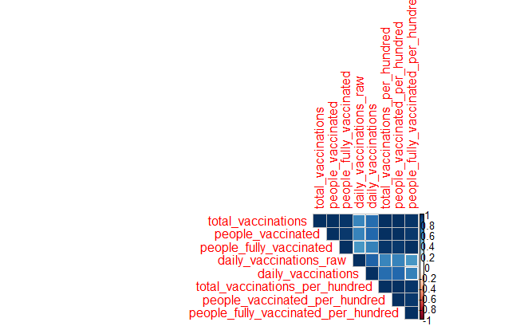

```r
corrplot(cor_vaccine, method ='square', type='upper',number.cex=10)
```

**Linear Regression**

```r
set.seed(123)
split<- sample.split(data_India$total_vaccinations, SplitRatio = 0.7)
train.data<- subset(data_India, split == T)
test.data <- subset(data_India, split == F)
```

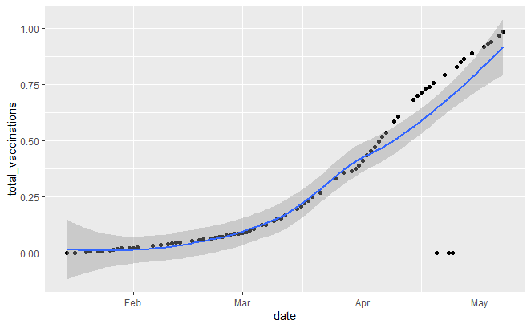

```r
ggplot(train.data, aes(date, total_vaccinations) ) +
  geom_point() +
  stat_smooth()
```

```r
# Build the model
model <- lm(total_vaccinations ~ date, data = train.data)
# Make predictions
predictions <- model %>% predict(test.data)
# Model performance
data.frame(
  RMSE = RMSE(predictions, test.data$total_vaccinations),
  R2 = R2(predictions, test.data$total_vaccinations)
)
```

| RMSE | R2 |
| --- | --- |
| 0.12189 | 0.8909202 |

```r
summary(model)
```

```
Call:
lm(formula = total_vaccinations ~ date, data = train.data)

Residuals:
     Min       1Q   Median       3Q      Max
-0.64013 -0.08923 -0.00270  0.12592  0.23812

Coefficients:
              Estimate Std. Error t value Pr(>|t|)
(Intercept) -1.551e+02  1.108e+01  -13.99   <2e-16 ***
date         8.308e-03  5.926e-04   14.02   <2e-16 ***
---
Signif. codes:  0 ‘***’ 0.001 ‘**’ 0.01 ‘*’ 0.05 ‘.’ 0.1 ‘ ’ 1

Residual standard error: 0.1685 on 77 degrees of freedom
Multiple R-squared:  0.7185,    Adjusted R-squared:  0.7149
F-statistic: 196.6 on 1 and 77 DF,  p-value: < 2.2e-16
```

**Plotting Linear Regression**

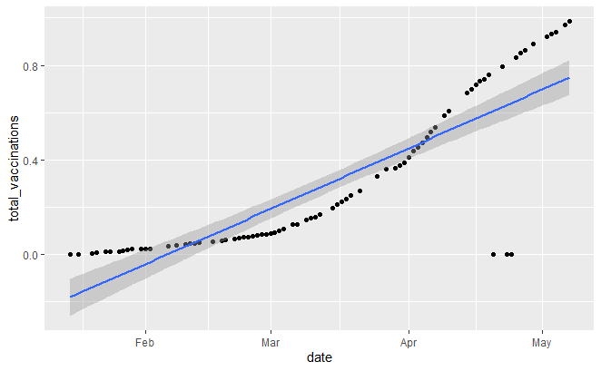

```r
ggplot(train.data, aes(date, total_vaccinations) ) +
  geom_point() +
  stat_smooth(method = lm, formula = y ~ x)
```

**Polynomial Regression**

```r
 #Build the model
class(data_India$date)
```

```
[1] "Date"
```

```r
train.data$date<-as.numeric(as.Date(train.data$date, origin = "1900-01-01"))
test.data$date<-as.numeric(as.Date(test.data$date, origin = "1900-01-01"))
model2 <- lm(total_vaccinations ~ poly(date, 5, raw = TRUE), data = train.data)
# Make predictions
predictions <- model2 %>% predict(test.data)
```

```
prediction from a rank-deficient fit may be misleading
```

```r
# Model performance
data.frame(
  RMSE = RMSE(predictions, test.data$total_vaccinations),
  R2 = R2(predictions, test.data$total_vaccinations)
)
```

| RMSE | R2 |
| --- | --- |
| 0.05514696 | 0.9923289 |

```r
summary(model2)
```

```
Call:
lm(formula = total_vaccinations ~ poly(date, 5, raw = TRUE),
    data = train.data)

Residuals:
     Min       1Q   Median       3Q      Max
-0.70629 -0.01237  0.00991  0.05867  0.13235

Coefficients: (3 not defined because of singularities)
                             Estimate Std. Error t value Pr(>|t|)
(Intercept)                 3.127e+04  6.148e+03   5.085 2.57e-06 ***
poly(date, 5, raw = TRUE)1 -3.352e+00  6.576e-01  -5.098 2.44e-06 ***
poly(date, 5, raw = TRUE)2  8.986e-05  1.758e-05   5.110 2.33e-06 ***
poly(date, 5, raw = TRUE)3         NA         NA      NA       NA
poly(date, 5, raw = TRUE)4         NA         NA      NA       NA
poly(date, 5, raw = TRUE)5         NA         NA      NA       NA
---
Signif. codes:  0 ‘***’ 0.001 ‘**’ 0.01 ‘*’ 0.05 ‘.’ 0.1 ‘ ’ 1

Residual standard error: 0.1463 on 76 degrees of freedom
Multiple R-squared:  0.7905,    Adjusted R-squared:  0.785
F-statistic: 143.4 on 2 and 76 DF,  p-value: < 2.2e-16
```

**Plotting Polynomial Regression**

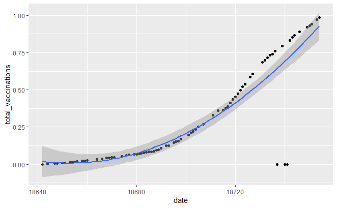

```r
ggplot(train.data, aes(date, total_vaccinations) ) +
  geom_point() +
  stat_smooth(method = lm, formula = y ~ poly(x, 5, raw = TRUE))
```